# Exam1-TakeHome

## Question 1:

- **When it is 8:00 in Lubbock,**
  - **It is 9:00 in New York**
  - **It is 14:00 in London**
  - **It is 15:00 in Cairo**
  - **It is 16:00 in Istanbul**
  - **It is 19:00 in Hyderabad**
  - **It is 22:00 in Tokyo**

**Write a function that reports the time in New York, London, Cairo, Istanbul, Hyderabad, and Tokyo based on the time in Lubbock. Use a 24-hour time format. Include error trapping that:**

1- Issues a message like "Please Enter A Number from 00 to 23" if the first input is numeric but outside the range of [0,23].  
2- Takes any numeric input for "Lubbock time" selection , and forces it into an integer.  
3- Issues an appropriate message if the user's selection is non-numeric.

**Check your function for these times:**

- 8:00
- 17:00
- 0:00

```python
#Suggested Solution:

def LBBtime():
    try:
        LBK = int(input('What hour is it in Lubbock?- Please enter a number from 0 to 23'))
        if LBK>23:
            print('Please Enter A Number from 00 to 23')
        if LBK<23 and LBK>=0:
            print("Time in New York is",LBK+1,":00")
            print("Time in London is",LBK+6,":00")
            print("Time in Cairo is",LBK+7,":00")
            print("Time in Istanbul is",LBK+8,":00")
            print("Time in Hyderabad is",LBK+11,":00")
            print("Time in Tokyo is",LBK+14,":00")
            return #null return
    except:
        print("Please Enter an Appropriate Input")
```

```python
LBBtime()
```

```
Please Enter an Appropriate Input
```

## Question 2:

Follow the steps below. Add comments to your script and signify when each step and each task is done. *hint: For this problem you will need the numpy and pandas libraries.

```python
#Suggested Solution:

#Step0:
import numpy as np
import pandas as pd
#Step1:
Rarray = np.array([[1,6,7,4],[5,2,3,8]])     #Define Rarray
print(Rarray)
#Step2:
print(np.max(Rarray))          #Find the maximum Value
print(np.argmax(Rarray))       #Find the posirtion of the maximum value
#Step3:
Rarraysort = np.sort(Rarray,axis = 1) #Sort Rarray along the rows and define a new array
print(Rarraysort)
#Step4:
DoubleRarray = np.array([[1,6,7,4],[5,2,3,8],[1,4,6,7],[2,3,5,8]])     #Define DoubleRarray
print(DoubleRarray)
#Step5:
SliceRarray = DoubleRarray[0:4,1:4]     #Slice DoubleRarray and Define SliceRarray
print(SliceRarray)
#Step6:
myrowname = ["Row A","Row B","Row C","Row D"]
mycolname = ["Column 1", "Column 2","Column 3"]
Rdataframe = pd.DataFrame(SliceRarray,myrowname,mycolname)     #Define Rdataframe
#Step7:
print(Rdataframe.head())     #Print the first few rows of the Rdataframe
#Step8:
Rdataframe['Column X']= None     #Add a new column, "Column X"
R2dataframe = Rdataframe         #Define R2dataframe
print(R2dataframe.info())               #Get the info
#Step9:
R2dataframe = R2dataframe.fillna(0)     #Replace NAs with 0
print(R2dataframe.describe())                 #Get the summary statistics
#Step10:
def myfunc(x):  # A user-built function
    y = (x**2) - (10*x) +7
    return(y)
R3dataframe = R2dataframe.apply(myfunc)     #Apply the function on the entire R2dataframe
print(R3dataframe)
print(R3dataframe.describe())
#Step11:
print(R3dataframe['Column 3'].value_counts())  #Returns the number of occurences of each unique value in Column 3
#Step12:
print(R3dataframe.sort_values('Column 1', ascending = False)) #Sorting based on Column 1
#Step13:
R3dataframe.to_csv('Rfile.csv')     #Write R3dataframe on a CSV file
#Step14:
readfilecsv = pd.read_csv('Rfile.csv') #Read the Rfile.csv
print(readfilecsv)         #Print the contents of the Rfile.csv
```

```
[[1 6 7 4]
 [5 2 3 8]]
8
7
[[1 4 6 7]
 [2 3 5 8]]
[[1 6 7 4]
 [5 2 3 8]
 [1 4 6 7]
 [2 3 5 8]]
[[6 7 4]
 [2 3 8]
 [4 6 7]
 [3 5 8]]
       Column 1  Column 2  Column 3
Row A         6         7         4
Row B         2         3         8
Row C         4         6         7
Row D         3         5         8
<class 'pandas.core.frame.DataFrame'>
Index: 4 entries, Row A to Row D
Data columns (total 4 columns):
 #   Column    Non-Null Count  Dtype
---  ------    --------------  -----
 0   Column 1  4 non-null      int64
 1   Column 2  4 non-null      int64
 2   Column 3  4 non-null      int64
 3   Column X  0 non-null      object
dtypes: int64(3), object(1)
memory usage: 160.0+ bytes
None
       Column 1  Column 2  Column 3  Column X
count  4.000000  4.000000  4.000000       4.0
mean   3.750000  5.250000  6.750000       0.0
std    1.707825  1.707825  1.892969       0.0
min    2.000000  3.000000  4.000000       0.0
25%    2.750000  4.500000  6.250000       0.0
50%    3.500000  5.500000  7.500000       0.0
75%    4.500000  6.250000  8.000000       0.0
max    6.000000  7.000000  8.000000       0.0
```

[output cut: 13 more lines]

```
max    -9.000000 -14.000000  -9.000000       7.0
-9     2
-14    1
-17    1
Name: Column 3, dtype: int64
       Column 1  Column 2  Column 3  Column X
Row B        -9       -14        -9         7
Row D       -14       -18        -9         7
Row A       -17       -14       -17         7
Row C       -17       -17       -14         7
  Unnamed: 0  Column 1  Column 2  Column 3  Column X
0      Row A       -17       -14       -17         7
1      Row B        -9       -14        -9         7
2      Row C       -17       -17       -14         7
3      Row D       -14       -18        -9         7
```

## Problem 3

Graphing Functions Special Functions

Consider the two functions listed below:

\begin{equation} f(x) = e^{-\alpha x} \label{eqn:fofx} \end{equation}\begin{equation} g(x) = \gamma sin(\beta x) \label{eqn:gofx} \end{equation}

Prepare a plot of the two functions on the same graph.

Use the values in Table below for $\alpha$, $\beta$, and $\gamma$.

[output not shown]

The plot should have $x$ values ranging from $0$ to $10$ (inclusive) in sufficiently small increments to see curvature in the two functions as well as to identify the number and approximate locations of intersections. In this problem, intersections are locations in the $x-y$ plane where the two "curves" cross one another of the two plots.

```python
# By-hand evaluate f(x) for x=1, alpha = 1/2
```

```python
# By-hand evaluate g(x) for x=3.14, beta = 1/2, gamma = 2
```

```python
# Define the first function f(x,alpha), test the function using your by hand answer
def f(x,alpha):
    import math
    f = math.exp(-1.0*alpha*x)
    return f

f(1,0.5)
```

```
0.6065306597126334
```

```python
# Define the second function g(x,beta,gamma), test the function using your by hand answer
def g(x,beta,gamma):
    import math
    f = gamma*math.sin(beta*x)
    return f

g(3.14,0.5,2.0)
```

```
1.9999993658636692
```

```python
# Built a list for x that ranges from 0 to 10, inclusive, with adjustable step sizes for plotting later on
howMany = 10
scale = 10.0/howMany
xvector = []
for i in range(0,howMany+1):
    xvector.append(scale*i)
#xvector # activate to display
```

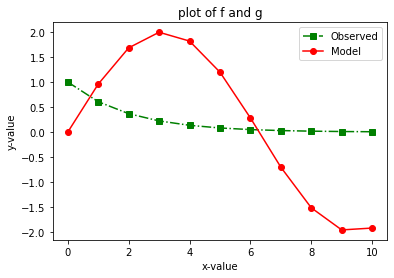

```python
# Build a plotting function that plots both functions on the same chart
alpha = 0.5
beta = 0.5
gamma = 2.0
yf = []
yg = []
for i in range(0,howMany+1):
    yf.append(f(xvector[i],alpha))
    yg.append(g(xvector[i],beta,gamma))

def plot2lines(list11,list21,list12,list22,strx,stry,strtitle): # plot list1 on x, list2 on y, xlabel, ylabel, title
    from matplotlib import pyplot as plt # import the plotting library from matplotlibplt.show()
    plt.plot( list11, list21, color ='green', marker ='s', linestyle ='dashdot' , label = "Observed" ) # create a line chart, years on x-axis, gdp on y-axis
    plt.plot( list12, list22, color ='red', marker ='o', linestyle ='solid' , label = "Model") # create a line chart, years on x-axis, gdp on y-axis
    plt.legend()
    plt.title(strtitle)# add a title
    plt.ylabel(stry)# add a label to the x and y-axes
    plt.xlabel(strx)
    plt.show() # display the plot
    return #null return

plot2lines(xvector,yf,xvector,yg,'x-value','y-value','plot of f and g')
```

```python
# Using the plot as a guide, find the values of x where the two curves intercept (i.e. f(x) = g(x))

xguess = float(input('my guess for x')) # ~0.7, and 6.25
alpha = 0.5
beta = 0.5
gamma = 2.0
result = f(xguess,alpha) - g(xguess,beta,gamma)
print('f(x) - g(x) =', result)
```

```
f(x) - g(x) = 0.010753149164711609
```

## Bonus Problem 1. Extra Credit (You must complete the regular problems)!

**create a class to compute the average grade (out of 10) of the students based on their grades in Quiz1, Quiz2, the Mid-term, Quiz3, and the Final exam.**

| Student Name | Quiz 1 | Quiz 2 | Mid-term | Quiz 3 | Final Exam |
| --- | --- | --- | --- | --- | --- |
| Harry | 8 | 9 | 8 | 10 | 9 |
| Ron | 7 | 8 | 8 | 7 | 9 |
| Hermione | 10 | 10 | 9 | 10 | 10 |
| Draco | 8 | 7 | 9 | 8 | 9 |
| Luna | 9 | 8 | 7 | 6 | 5 |

"Student Name": **Average Grade**

1. **Create and print out a dictionary with the student names as keys and their average grades as data.**

```python
#Suggested Solution:

class Hogwarts:
    """This class calculates the average grade of the students"""
    def __init__(self, Name,Quiz1,Quiz2,MidTerm,Quiz3,Final):
        self.Name = Name
        self.Quiz1 = Quiz1
        self.Quiz2 = Quiz2
        self.MidTerm = MidTerm
        self.Quiz3 = Quiz3
        self.Final= Final

    def average(self):
        return (self.Quiz1 + self.Quiz2 + self.MidTerm + self.Quiz3 + self.Final) /5


S1 = Hogwarts('Harry',8,9,8,10,9)                      #Fill the instances
S2 = Hogwarts('Ron',7,8,8,7,9)
S3 = Hogwarts('Hermione',10,10,9,10,10)
S4 = Hogwarts('Draco',8,7,9,8,9)
S5 = Hogwarts('Luna',9,8,7,6,5)

print("Harry", S1.average())
print("Ron", S2.average())
print("Hermione", S3.average())
print("Draco", S4.average())
print("Luna", S5.average())

GradeDict = {"Harry":S1.average(),"Ron":S2.average(),"Hermione":S3.average(),"Draco":S4.average(),"Luna":S5.average()}
print(GradeDict)
```

```
Harry 8.8
Ron 7.8
Hermione 9.8
Draco 8.2
Luna 7.0
{'Harry': 8.8, 'Ron': 7.8, 'Hermione': 9.8, 'Draco': 8.2, 'Luna': 7.0}
```

## Bonus 2 Extra credit (You must complete the regular problems)!

#### Write the VOLUME Function to compute the volume of Cylinders, Spheres, Cones, and Rectangular Boxes. This function should:

- First, ask the user about **the shape of the object** of interest using this statement:  
  *"Please choose the shape of the object. Enter 1 for "Cylinder", 2 for "Sphere", 3 for "Cone", or 4 for "Rectangular Box""*
- Second, based on user's choice in the previous step, **ask for the right inputs**.
- Third, print out an statement with **the input values and the calculated volumes**.

#### Include error trapping that:

1. Issues a message that *"The object should be either a Cylinder, a Sphere, a Cone, or a Rectangular Box. Please Enter A Number from 1,2,3, and 4!"* if the first input is non-numeric.
2. Takes any numeric input for the initial selection , and force it into an integer.
3. Issues an appropriate message if the user's selection is numeric but outside the range of [1,4]
4. Takes any numeric input for the shape characteristics , and force it into a float.
5. Issues an appropriate message if the object characteristics are as non-numerics.

#### Test the script for:

1. **Sphere, r=10**
2. **r=10 , Sphere**
3. **Rectangular Box, w=5, h=10, l=0.5**
- __Volume of a Cylinder = πr²h__
- __Volume of a Sphere = 4(πr3)/3__
- __Volume of a Cone = (πr²h)/3__
- __Volume of a Rectangular Box = whl__

```python
#Suggested Solution:

import numpy as np # import NumPy: for large, multi-dimensional arrays and matrices, along with  high-level mathematical functions to operate on these arrays.
pi = np.pi #pi value from the np package

def VOLUME():
    try:
        UI = input('Please choose the shape of the object. Enter 1 for "Cylinder", 2 for "Sphere", 3 for "Cone", or 4 for "Rectangular Box"')
        UI =int(UI)
        if UI==1:
                try:
                    UI2 = input('Please enter the radius of the Cylinder')
                    r= float(UI2)
                    UI3 = input('Please enter the height of the Cylinder')
                    h= float(UI3)
                    V= pi*h*r**2
                    print("The volume of the Cylinder with the radius of ",r," and the height of ",h," is equal to", V)
                except:
                    print("The radius and height of the Cylinder must be numerics. Please Try Again!")
        elif UI==2:
                try:
                    UI2 = input('Please enter the radius of the Sphere')
                    r= float(UI2)
                    V= (4*pi*r**3)/3
                    print("The volume of the Sphere with the radius of ",r," is equal to", V)
                except:
                    print("The radius of the Sphere must be numeric. Please Try Again!")
        elif UI==3:
                try:
                    UI2 = input('Please enter the radius of the Cone')
                    r= float(UI2)
                    UI3 = input('Please enter the height of the Cone')
                    h= float(UI3)
                    V= (pi*h*r**2)/3
                    print("The volume of the Cone with the radius of ",r," and the height of ",h," is equal to", V)
                except:
                    print("The radius and height of the Cone must be numerics. Please Try Again!")
        elif UI==4:
                try:
                    UI2 = input('Please enter the width of the Rectangular Box')
                    w= float(UI2)
                    UI3 = input('Please enter the height of the Rectangular Box')
                    h= float(UI3)
                    UI4 = input('Please enter the length of the Rectangular Box')
                    l= float(UI4)
                    V= w*h*l
                    print("The volume of the Rectangular Box with the width of ",w," and the height of ",h," and the length of ",l," is equal to", V)
                except:
                    print("The width, height, and length of the Rectangular Box must be numerics. Please Try Again!")
        else:
            print("Please Enter A Number from 1,2,3, and 4!")

    except:
        print("The object should be either a Cylinder, a Sphere, a Cone, or a Rectangular Box. Please Enter A Number from 1,2,3, and 4!")
```

```python
VOLUME()
```

```
The volume of the Cylinder with the radius of  3.0  and the height of  3.0  is equal to 84.82300164692441
```